# Cambridge Makerere Summer School

Essential preparations prior to attending Bioinformatics workshop

Ashley Sawle

6th September 2023

# 1 Installing R and RStudio

**R** and **RStudio** are separate downloads and installations.

**R** is the underlying statistical computing environment. The base R system and a very large collection of packages that give you access to a huge range of statistical and analytical functionality are available from [CRAN](https://cran.r-project.org), the Comprehensive R Archive Network.

**RStudio** is a graphical integrated development environment (IDE) that makes using R much easier and more interactive.

You need to first install R before you install RStudio. The instructions are slightly different depending on your operating system/computer platform. Please use the relevant instruction below.

If you already have R and RStudio installed on your laptop, please make sure they are both up to date and update any packages that you already have installed.

## Installation on Windows

### Installing R

1. Download the current version of R (version 4.3.1 as of 06/09/2023) from the [CRAN website](https://cran.r-project.org/bin/windows/base).
2. Double click the `.exe` file that was just downloaded to launch it and install R

### Installing RStudio

1. Go to the [RStudio download page](https://posit.co/download/rstudio-desktop/#download)
2. Under *Installers* download **RStudio-2023.06.2-561.exe**
3. Double click the file to install it

## Installation on Apple MacBook

### Installing R

Apple MacBooks come with one of two types of cpu (chip) - Intel or Apple M1/M2. A different version of R needs to be installed depending on the type of chip that is running your MacBook. So, the first thing you should do is check what chip your Mac has. Once you know this, you can download the relevant R version and install it.

1. Click on Apple logo in top left of the screen, then chick on `About This Mac`. Check to see whether you have an “Intel” or an “Apple M” chip:

[figure not shown]

2. Download the appropriate version of R for your chip from the [CRAN website](https://cran.r-project.org/bin/macosx/):

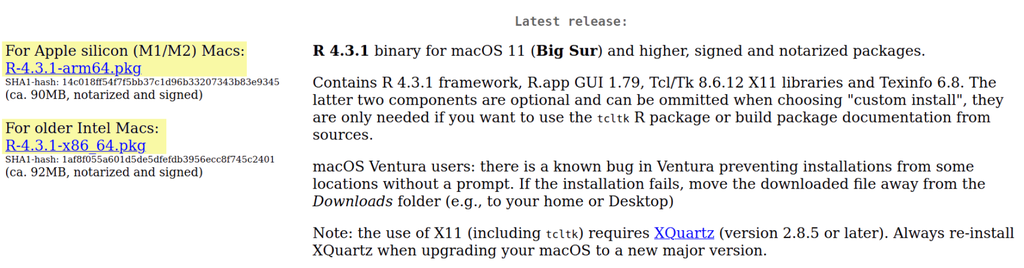

3. Double click on the downloaded file to install R

### Installing XQuartz

In order to run RStudio on Mac OS you will need to install an additional piece of software - XQuartz.

1. Download the `.pkg` file from [XQuartz](https://www.xquartz.org/).
2. Double click the downloaded file to install XQuartz

### Installing RStudio

Finally install RStudio:

1. Go to the [RStudio download page](https://posit.co/download/rstudio-desktop/#download)
2. Under *Installers* select **Mac OS 11+ RStudio-2023.06.2-561.DMG**
3. Double click the donwloaded file to install RStudio

## Updating existing R and RStudio

If you already have R and RStudio installed, you should make sure that you are running the latest versions.

First check RStudio and update if necessary. Open RStudio, and click on `Help` in the menu bar and then `Check for updates`.

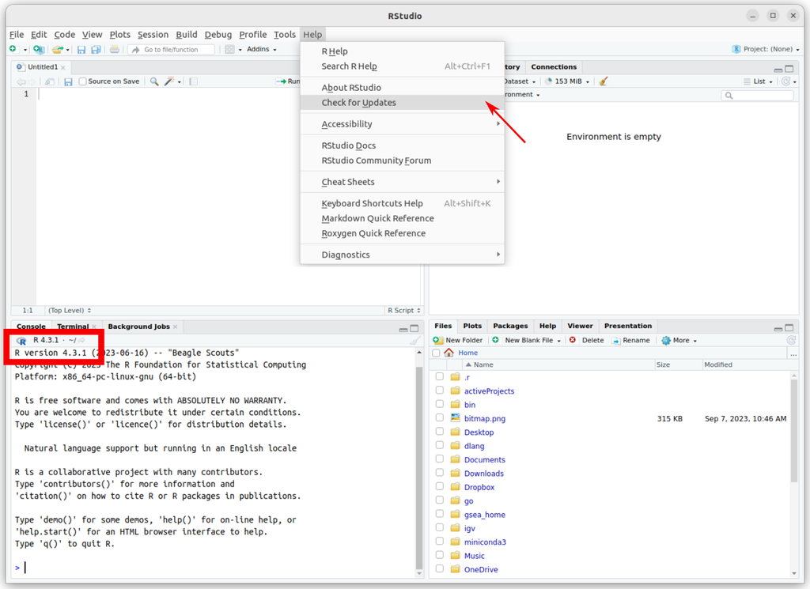

If either R or RStudio requires updating, close RStudio and then folow the relevant installation instructions for your platform (Windows or macOS).

# 2 Installing the `tidyverse` R package

In the “R intro” workshop we will be learning how to work with data using a suite of packages collectively known as “the tidyverse”. This is includes packages such as `readr`, `dplyr` and `ggplot2`. Rather than install each package separately we can conveniently install them all at once by installing the `tidyverse` package.

To install the `tidyverse` packages:

Start RStudio, at the console type

```r
install.packages("tidyverse")
```

and then press `Enter`:

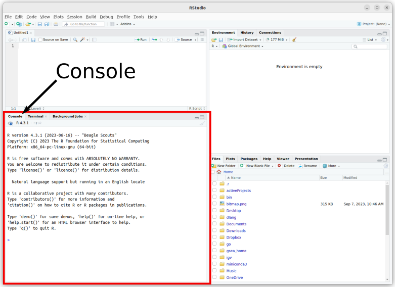

[figure not shown]

You should then see some messages as the tidyverse is installed:

[figure not shown]

Finally, check that the tidyverse has been installed by loading it from your library. To do this, at the console type:

```r
library(tidyverse)
```

and press `Enter`. You should see the following message (or similar):

[figure not shown]

# 3 Installing packages for the “Differential Gene Expression Analysis” workshop

For the “Differential Gene Expression Analysis of RNAseq data with DESeq2 in R” workshop we will need a number of packages. Some are specific for differential gene expression analysis, others for annotation of genes based on gene IDs and other are simply helper packages for creating plots. Many of the packages we will be using come from the [Bioconductor](https://bioconductor.org/) project. Bioconductor is an open project that curates R packages specifically for analysis of biological data. Bioconductor packages are kept in a different repository to CRAN packages (such as the tidyverse, which you should have already installed) and so require a different function to install them.

Before installing the packages we need, we must first install the latest version of Bioconductor. **It is essential that your R and RStudio are up to date before doing this.** It is not possible to install the current version of Bioconductor in older versions of R.

## 3.1 Install Bioconductor

1. First we need to install the `BiocManager` package. Start RStudio, at the console run the command:

```r
install.packages("BiocManager")
```

2. Now we can install Bioconductor. At the console type:

```r
BiocManager::install(version = "3.17")
```

If this is the first time you are installing Bioconductor, it can take some time.

## 3.2 Install Packages

Although we are going to be installing packages from both CRAN and Bioconductor we can use `BiocManager::install` to install all the packages - it will figure out whether to use CRAN or Bioconductor for each package.

1. To install all of the packages we need for the RNAseq course, type (or copy/paste) the following command into the console.

```r
BiocManager::install(c("AnnotationDbi", "AnnotationHub", "circlize",
                       "clusterProfiler", "ComplexHeatmap", "DESeq2",
                       "enrichplot", "ensembldb", "gganimate", "ggdendro",
                       "ggfortify", "ggrepel", "ggvenn", "janitor", "msigdbr",
                       "org.Mm.eg.db", "pathview", "tximport"))
```

Again, it may take some time to install all of the packages.

2. Once the installation is complete, type (or copy/paste) each of the following lines to ensure you have correctly installed all the packages.

```r
library(AnnotationDbi)
library(AnnotationHub)
library(circlize)
library(clusterProfiler)
library(ComplexHeatmap)
library(DESeq2)
library(enrichplot)
library(ensembldb)
library(gganimate)
library(ggdendro)
library(ggfortify)
library(ggrepel)
library(ggvenn)
library(janitor)
library(msigdbr)
library(org.Mm.eg.db)
library(pathview)
library(tidyverse)
library(tximport)
```

If a package has not installed correctly you will get a message similar to this:

[figure not shown]

# 4 Downloading the Data

We will need various data files for the workshops. These can all be downloaded in a single zip file from [here](https://bioinformatics-core-shared-training.github.io/Reverse_Summer_School_2023_PreCourse/Bioinformatics_workshop_data.zip).

Please download this file and unzip in a suitable location on your laptop. We will be working within this folder for the duration of the workshops.